# EDAV Fall 2019 PSet 5, part A

This assignment is designed to help you get started on the final project. Be sure to review the final project instructions (https://edav.info/project.html), in particular the new section on reproducible workflow (https://edav.info/project.html#reproducible-workflow), which summarizes principles that we’ve discussed in class.

### 1. The Team

[2 points]

1. Who’s on the team? (Include names and UNIs)

Yitao Liu (yl4343), Boyu Liu(bl2788), Yiyang Sun(ys3284)

2. How do you plan to divide up the work? (Grading is on a group basis. The point of asking is to encourage you to think about this.)

First of all, we want to do the data preprocessing first together. Then we will split the work by exploring at different aspects of the data. Specifically, everyone will focus on one of the three questions.

### 2. The Questions

[6 points]

List three questions that you hope you will be able to answer from your research.

1. With time going, how voilence pattern changes in all regions.
2. What’s the difference for conflict patterns in different regions.
3. Whether thers is correlation between number of deaths and time or region.

### 3. Which output format do you plan to use to submit the project?

[2 points]

We choose html_document as the output format.

### 4. The Data

[5 points]

UCDP Georeferenced Event Dataset (GED) Global version 19.1 from UCDP Dataset (https://ucdp.uu.se/downloads/index.html#ged_global) The dataset has a RData version which we can directly load using R, so we don’t have any obstacle. The dataset contains records of armed conflicts that take place in the world from 1989 to 2018. The data include information like countries/parties of the conflict, its start and end times, the number of deaths caused by the conflict, etc.

The original dataset lists conflicts based on their ids. Different conflicts have different durations. Some conflicts last for one day while some others last for months. In the future studies of this project, we might be interested in finding the pattern based on day/month. Therefore, in the data processing stage, we may want to transform the original dataset into a new one, which records the conflict based on each date or mothn, as follows (the example below is based on date):

The transformed dataset is on our [Project GitHub Repo](https://github.com/tonyytliu/edav_final_project).

```r
df_0 <- data.frame(id=c(01,02), date_start=c("2000-01-01", "2000-01-01"),
                   date_end=c("2000-01-01", "2000-01-03"),
                   death=c(10,90))
df_1 <- data.frame(id=c(01,02, 02, 02),
                   date_start=c("2000-01-01", "2000-01-01", "2000-01-01", "2000-01-01"),
                   date_end=c("2000-01-01", "2000-01-03", "2000-01-03", "2000-01-03"),
                   dates = c("2000-01-01", "2000-01-01", "2000-01-02", "2000-01-03"),
                   death=c(10,90,90,90),
                   avg_death = c(10,30,30,30))
```

transform

```r
knitr::kable(df_0)
```

| id | date_start | date_end | death |
| --- | --- | --- | --- |
| 1 | 2000-01-01 | 2000-01-01 | 10 |
| 2 | 2000-01-01 | 2000-01-03 | 90 |

to

```r
knitr::kable(df_1)
```

| id | date_start | date_end | dates | death | avg_death |
| --- | --- | --- | --- | --- | --- |
| 1 | 2000-01-01 | 2000-01-01 | 2000-01-01 | 10 | 10 |
| 2 | 2000-01-01 | 2000-01-03 | 2000-01-01 | 90 | 30 |
| 2 | 2000-01-01 | 2000-01-03 | 2000-01-02 | 90 | 30 |
| 2 | 2000-01-01 | 2000-01-03 | 2000-01-03 | 90 | 30 |

### 5. Provide a short summary, including 2-3 graphs, of your initial investigations.

[10 points]

In the initial investigations, we examined the number of conflicts that occurred in each year, the number of conflict-caused deaths in each year, and the geometric distribution of the conflict. Our summaries of those investigations are included in the following four subsections.

#### 1. Number of conflicts based on year

```r
# Load the Dataset
load(here("data", "raw", "ged191.RData"))
df_process <- ged191 %>%
              mutate(date_start = as.Date(date_start),
                     date_end = as.Date(date_end))
df_count <- df_process %>%
            group_by(year) %>%
            tally()
```

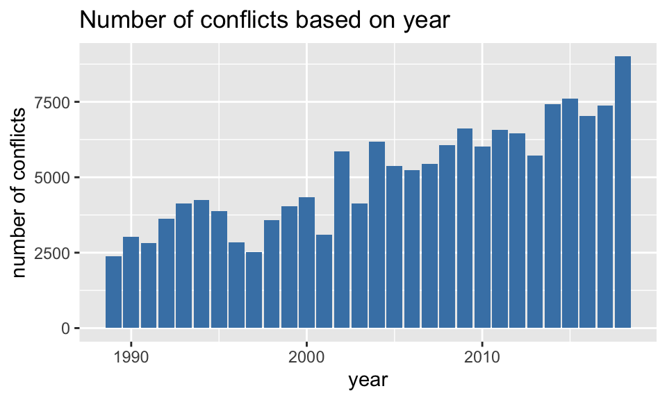

```r
ggplot(df_count, aes(x = year, y = n)) +
      geom_bar(stat = "identity", fill = "steelblue") +
      ggtitle("Number of conflicts based on year") +
      labs(y = "number of conflicts")
```

#### 2. Distribution of the number of deaths based on conflict

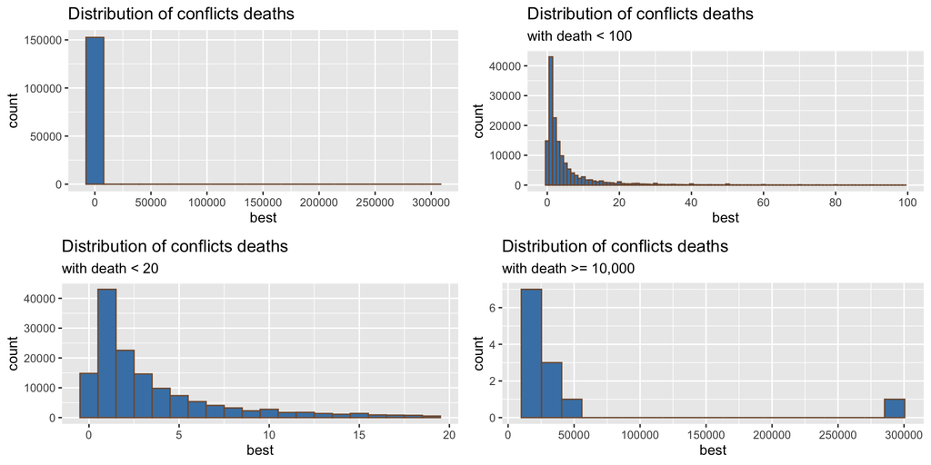

```r
g1 <- ggplot(df_process, aes(x = best)) +
        geom_histogram(bins = 20, colour = "#80593D", fill = "steelblue") +
        scale_x_continuous(breaks= pretty_breaks()) +
        ggtitle("Distribution of conflicts deaths")
# only small values
df_process2 <- df_process %>%
              filter(best < 100)
g2<- ggplot(df_process2, aes(x = best)) +
        geom_histogram(bins = 100, colour = "#80593D", fill = "steelblue") +
        scale_x_continuous(breaks= pretty_breaks()) +
        ggtitle("Distribution of conflicts deaths",
                subtitle = "with death < 100")

df_process3 <- df_process %>%
              filter(best < 20)
g3<- ggplot(df_process3, aes(x = best)) +
        geom_histogram(bins = 20, colour = "#80593D", fill = "steelblue") +
        scale_x_continuous(breaks= pretty_breaks()) +
        ggtitle("Distribution of conflicts deaths",
                subtitle = "with death < 20")

df_process4<- df_process %>%
              filter(best >= 10000)
g4<- ggplot(df_process4, aes(x = best)) +
        geom_histogram(bins = 20, colour = "#80593D", fill = "steelblue", boundary=10000) +
        scale_x_continuous(breaks= pretty_breaks()) +
        ggtitle("Distribution of conflicts deaths",
                subtitle = "with death >= 10,000")

ggarrange(g1, g2, g3, g4, ncol = 2, nrow = 2)
```

```r
# The conflict with largest death
df_2<- head(df_process[order(-df_process$best),], 10)[c("side_a", "side_b", "year", "best")]
knitr::kable(df_2)
```

|  | side_a | side_b | year | best |
| --- | --- | --- | --- | --- |
| 13767 | Government of Rwanda | Civilians | 1994 | 300557 |
| 47072 | Government of Eritrea | Government of Ethiopia | 2000 | 48183 |
| 35731 | Government of Rwanda | Civilians | 1994 | 40000 |
| 21448 | Government of Eritrea | Government of Ethiopia | 1999 | 30000 |
| 35679 | Government of Rwanda | Civilians | 1994 | 27500 |
| 14095 | Government of Rwanda | Civilians | 1994 | 20000 |
| 35647 | Government of Rwanda | Civilians | 1994 | 16890 |
| 20705 | Government of Eritrea | Government of Ethiopia | 1999 | 15000 |
| 1943 | Government of Rwanda | Civilians | 1994 | 12000 |
| 35674 | Government of Rwanda | Civilians | 1994 | 11170 |

As shown in the top-left plot, the dataset is highly skewed and imbalanced. When we focus on the data with death less than 100 people, we can see the data are more concentrated in <20 regions. Most conflicts have less than five deaths.

We also see that there are several conflicts with an extremely high number of deaths (>10,000). After an investigation of those conflicts, we found out most of them are related to the [Rwanda genocide](https://en.wikipedia.org/wiki/Rwandan_genocide), which was taken place in 1994.

(Note: `best` variable in the dataset means the best estimatation of the death in the conflict).

#### 3. Number of deaths based on year

```r
# get conflicts' deaths by year
df_sum <- df_process %>%
            group_by(year) %>%
            summarise_at(vars(best), funs(sum))


# get conflicts related with the Rwanda genocide
df_rwa <- df_process %>%
          filter(side_a == "Government of Rwanda",
                 side_b == "Civilians",
                 date_end <= as.Date("1994-07-31"),
                 date_start >= as.Date("1994-04-01"))
# get conflicts' deaths by year without the Rwanda genocide
df_sum2 <- df_process %>%
            filter(!(df_process$id %in% df_rwa$id)) %>%
            group_by(year) %>%
            summarise_at(vars(best), funs(sum))
```

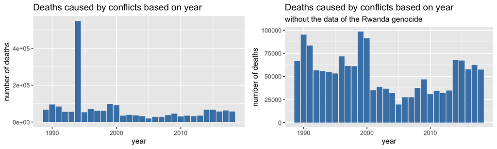

```r
g5<- ggplot(df_sum, aes(x = year, y = best)) +
        geom_bar(stat = "identity", fill = "steelblue") +
        ggtitle("Deaths caused by conflicts based on year") +
        labs(y = "number of deaths")

g6<- ggplot(df_sum2, aes(x = year, y = best)) +
        geom_bar(stat = "identity", fill = "steelblue") +
        ggtitle("Deaths caused by conflicts based on year",
                subtitle="without the data of the Rwanda genocide") +
        labs(y = "number of deaths")

ggarrange(g5, g6, ncol = 2, nrow = 1)
```

The conflict-caused deaths are extremely high in 1994, as shown in the left plot. As mentioned in the previous point, a high number of deaths were probably related to the Rwanda genocide. When we filter out the data related to the Rwanda genocide, we get the plot on the right. The conflict-caused death per year decreased from 1989 until 2005, after 2005, the number tends to increase.

#### 4. Location of conflicts

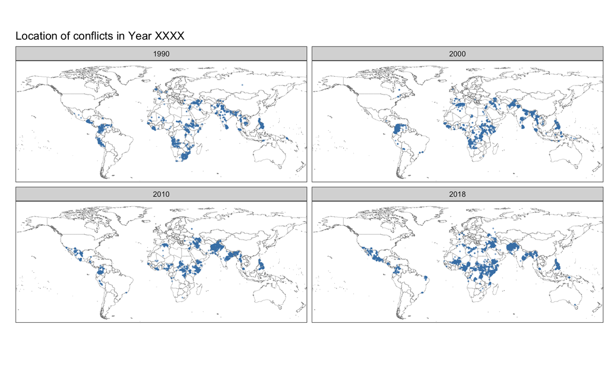

```r
# template code for plotting map from  https://stackoverflow.com/questions/30706124/plotting-the-world-map-in-r

WorldData <- map_data('world') %>% filter(region != "Antarctica") %>% fortify

temp <- df_process %>% filter(year %in% c(1990,2000,2010,2018))

ggplot() +
    geom_map(data = WorldData, map = WorldData,
                  aes(x = long, y = lat, group = group, map_id=region),
                  fill = "white", colour = "#7f7f7f", size=0.1) +
    geom_point(data=temp, aes(x=longitude, y=latitude),
               size=0.3, alpha=0.5, color="steelblue") +
    coord_map("rectangular", lat0=0, xlim=c(-180,180), ylim=c(-60, 90)) +
    facet_wrap(~year, ncol=2) +
    scale_fill_continuous(low="thistle2", high="darkred", guide="colorbar") +
    scale_y_continuous(breaks=c()) +
    scale_x_continuous(breaks=c()) +
    labs(fill="legend", title="Location of conflicts in Year XXXX", x="", y="") +
    theme_bw()
```

We chose four years (1990, 2000, 2010, 2018) to check the locations of conflict for this problem set. As shown in the map plots above, the rough geometrical distribution of the conflicts seems to have little changes. Most of the conflicts in all of those four years took place in Latin America, Africa, the Middle East, South Asia, and the Philippines.

However, if we take a look closely, the location patterns still have some changes across the years. For example, Mexico had only a few conflicts in 2000, but in 2010 and 2018, its numbers of conflicts increased. Another example, the number of conflicts in Sri Lanka decreased when comparing its numbers in 1990/2000 with the numbers 2010/2018, which is probably a result of the end of the [Sri Lankan Civil War](https://en.wikipedia.org/wiki/Sri_Lankan_Civil_War) in 2009.